# Simulating the 2021 CFB Season

Phil Henrickson & Trevor Cross

2022-08-12

# What is this?

Which teams are most likely to win their conference in 2021? Make the playoff? Win the national championship?

This notebook details results from simulating the 2021 college football season before any actual games are played. We use historical college football play by play and game data in order to develop a model for simulating upcoming games. All data is from collegefootballdata.com.

# 1 2021 Team Ratings

The following table displays each team’s **Rating**, which is estimated from their previous season’s Elo Rating, offensive efficiency, defensive efficiency, and a moving average of their composite recruiting score. These ratings are used to simulate the outcome of each game in an Elo framework, adjusting for home field advantage.

These ratings are **Week 0** ratings because they rely only on information from previous seasons. As the season progresses, these ratings will update for each team as we gain new information based on the results of games (with the exception of recruiting, which is computed at the yearly level).

| Rank | Conference | Team | Rating | Offense | Defense | Recruiting |
| --- | --- | --- | --- | --- | --- | --- |
| 1 | SEC | Alabama | 2045 | 0.386 | 0.097 | 317 |
| 2 | Big Ten | Ohio State | 1928 | 0.267 | 0.049 | 298 |
| 3 | ACC | Clemson | 1911 | 0.147 | 0.191 | 288 |
| 4 | Big 12 | Oklahoma | 1868 | 0.158 | 0.158 | 267 |
| 5 | SEC | Georgia | 1867 | 0.045 | 0.21 | 303 |
| 6 | SEC | Texas A&M | 1831 | 0.068 | 0.099 | 279 |
| 7 | FBS Independents | Notre Dame | 1799 | 0.082 | 0.072 | 262 |
| 8 | FBS Independents | BYU | 1780 | 0.3 | 0.106 | 160 |
| 9 | SEC | Florida | 1776 | 0.193 | 0.019 | 266 |
| 10 | Big 12 | Texas | 1771 | 0.125 | 0.084 | 260 |

[output cut: 120 more lines]

Note: for teams that are new to FBS this year, we do not have information on their previous offensive/defensive efficiency, so their initial rating comes from an Elo model based only on their results against FBS teams in previous seasons.

## 1.1 Team Ratings by Conference

The following visualization shows the distribution of each team’s Week 0 rating by conference.

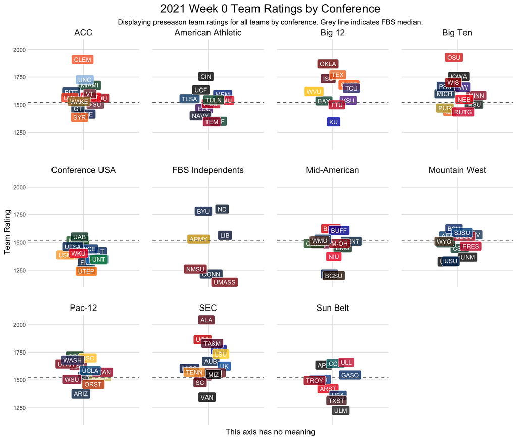

# 2 2021 Predictions

The following table shows each team’s strength of schedule (SOS), predicted record (for the regular season), probability of making a bowl, winning their conference championship, and making/winning in the playoff.

These results are based on simulating the 2021 season 1000 times and counting the number of simulations in which a team achieved each outcome.

| Conference | Team | SOS | Record | Bowl | Win_Conf | Playoff | Make_NC | Win_NC |
| --- | --- | --- | --- | --- | --- | --- | --- | --- |
| SEC | Alabama | 35 | 10.7 - 1.9 | 1 | 0.368 | 0.738 | 0.475 | 0.304 |
| Big Ten | Ohio State | 54 | 10.5 - 2.1 | 0.997 | 0.521 | 0.557 | 0.292 | 0.136 |
| ACC | Clemson | 84 | 10.4 - 2.1 | 0.994 | 0.503 | 0.51 | 0.236 | 0.107 |
| Big 12 | Oklahoma | 49 | 9.9 - 2.5 | 0.984 | 0.372 | 0.344 | 0.18 | 0.079 |
| SEC | Georgia | 32 | 9.6 - 2.7 | 0.983 | 0.202 | 0.253 | 0.13 | 0.066 |
| SEC | Texas A&M | 37 | 9.3 - 2.9 | 0.976 | 0.107 | 0.182 | 0.098 | 0.049 |
| Big 12 | Texas | 12 | 8.3 - 3.9 | 0.9 | 0.197 | 0.125 | 0.061 | 0.024 |
| FBS Independents | Notre Dame | 19 | 8.9 - 3.4 | 0.92 | 0 | 0.088 | 0.037 | 0.022 |
| SEC | Florida | 46 | 8.6 - 3.5 | 0.952 | 0.1 | 0.1 | 0.044 | 0.022 |
| Big Ten | Iowa | 27 | 8.5 - 3.7 | 0.901 | 0.131 | 0.093 | 0.047 | 0.019 |

[output cut: 120 more lines]

## 2.1 Conference Championship Predictions

These tables display the probability that each team will win their conference or finish as the runner-up.

### 2.1.1 SEC

| 2021 Conference Championship Probabilties Season | 2021 Conference Championship Probabilties Conference | 2021 Conference Championship Probabilties Division | 2021 Conference Championship Probabilties Team | 2021 Conference Championship Probabilties Champion | 2021 Conference Championship Probabilties Runner-Up |
| --- | --- | --- | --- | --- | --- |
| 2021 | SEC | East | Georgia | 0.202 | 0.321 |
| 2021 | SEC | East | Florida | 0.100 | 0.138 |
| 2021 | SEC | East | Kentucky | 0.021 | 0.055 |
| 2021 | SEC | East | Tennessee | 0.018 | 0.074 |
| 2021 | SEC | East | Missouri | 0.010 | 0.033 |
| 2021 | SEC | East | South Carolina | 0.006 | 0.018 |
| 2021 | SEC | East | Vanderbilt | 0.000 | 0.004 |
| 2021 | SEC | West | Alabama | 0.368 | 0.116 |
| 2021 | SEC | West | LSU | 0.133 | 0.142 |
| 2021 | SEC | West | Texas A&M | 0.107 | 0.062 |
| 2021 | SEC | West | Auburn | 0.017 | 0.010 |
| 2021 | SEC | West | Ole Miss | 0.009 | 0.010 |
| 2021 | SEC | West | Mississippi State | 0.005 | 0.009 |
| 2021 | SEC | West | Arkansas | 0.004 | 0.008 |

### 2.1.2 Big Ten

| 2021 Conference Championship Probabilties Season | 2021 Conference Championship Probabilties Conference | 2021 Conference Championship Probabilties Division | 2021 Conference Championship Probabilties Team | 2021 Conference Championship Probabilties Champion | 2021 Conference Championship Probabilties Runner-Up |
| --- | --- | --- | --- | --- | --- |
| 2021 | Big Ten | East | Ohio State | 0.521 | 0.227 |
| 2021 | Big Ten | East | Indiana | 0.043 | 0.034 |
| 2021 | Big Ten | East | Penn State | 0.040 | 0.039 |
| 2021 | Big Ten | East | Michigan | 0.031 | 0.028 |
| 2021 | Big Ten | East | Maryland | 0.013 | 0.013 |
| 2021 | Big Ten | East | Michigan State | 0.003 | 0.005 |
| 2021 | Big Ten | East | Rutgers | 0.000 | 0.003 |
| 2021 | Big Ten | West | Iowa | 0.131 | 0.186 |
| 2021 | Big Ten | West | Wisconsin | 0.116 | 0.239 |
| 2021 | Big Ten | West | Northwestern | 0.061 | 0.112 |
| 2021 | Big Ten | West | Minnesota | 0.020 | 0.047 |
| 2021 | Big Ten | West | Nebraska | 0.014 | 0.038 |
| 2021 | Big Ten | West | Illinois | 0.004 | 0.019 |
| 2021 | Big Ten | West | Purdue | 0.003 | 0.010 |

### 2.1.3 Big 12

| 2021 Conference Championship Probabilties Season | 2021 Conference Championship Probabilties Conference | 2021 Conference Championship Probabilties Division | 2021 Conference Championship Probabilties Team | 2021 Conference Championship Probabilties Champion | 2021 Conference Championship Probabilties Runner-Up |
| --- | --- | --- | --- | --- | --- |
| 2021 | Big 12 |  | Oklahoma | 0.372 | 0.257 |
| 2021 | Big 12 |  | Texas | 0.197 | 0.182 |
| 2021 | Big 12 |  | Iowa State | 0.157 | 0.159 |
| 2021 | Big 12 |  | Oklahoma State | 0.084 | 0.128 |
| 2021 | Big 12 |  | TCU | 0.077 | 0.067 |
| 2021 | Big 12 |  | West Virginia | 0.056 | 0.071 |
| 2021 | Big 12 |  | Baylor | 0.022 | 0.045 |
| 2021 | Big 12 |  | Kansas State | 0.022 | 0.056 |
| 2021 | Big 12 |  | Texas Tech | 0.011 | 0.030 |
| 2021 | Big 12 |  | Kansas | 0.002 | 0.005 |

### 2.1.4 ACC

| 2021 Conference Championship Probabilties Season | 2021 Conference Championship Probabilties Conference | 2021 Conference Championship Probabilties Division | 2021 Conference Championship Probabilties Team | 2021 Conference Championship Probabilties Champion | 2021 Conference Championship Probabilties Runner-Up |
| --- | --- | --- | --- | --- | --- |
| 2021 | ACC | Atlantic | Clemson | 0.503 | 0.224 |
| 2021 | ACC | Atlantic | Louisville | 0.038 | 0.045 |
| 2021 | ACC | Atlantic | NC State | 0.030 | 0.034 |
| 2021 | ACC | Atlantic | Wake Forest | 0.023 | 0.028 |
| 2021 | ACC | Atlantic | Boston College | 0.020 | 0.020 |
| 2021 | ACC | Atlantic | Florida State | 0.008 | 0.014 |
| 2021 | ACC | Atlantic | Syracuse | 0.003 | 0.010 |
| 2021 | ACC | Coastal | North Carolina | 0.170 | 0.246 |
| 2021 | ACC | Coastal | Miami | 0.081 | 0.138 |
| 2021 | ACC | Coastal | Virginia Tech | 0.048 | 0.083 |
| 2021 | ACC | Coastal | Pittsburgh | 0.043 | 0.079 |
| 2021 | ACC | Coastal | Virginia | 0.016 | 0.037 |
| 2021 | ACC | Coastal | Duke | 0.010 | 0.018 |
| 2021 | ACC | Coastal | Georgia Tech | 0.007 | 0.024 |

### 2.1.5 Pac-12

| 2021 Conference Championship Probabilties Season | 2021 Conference Championship Probabilties Conference | 2021 Conference Championship Probabilties Division | 2021 Conference Championship Probabilties Team | 2021 Conference Championship Probabilties Champion | 2021 Conference Championship Probabilties Runner-Up |
| --- | --- | --- | --- | --- | --- |
| 2021 | Pac-12 |  | Oregon | 0.230 | 0.156 |
| 2021 | Pac-12 |  | USC | 0.172 | 0.199 |
| 2021 | Pac-12 |  | Washington | 0.154 | 0.194 |
| 2021 | Pac-12 |  | Utah | 0.122 | 0.130 |
| 2021 | Pac-12 |  | Arizona State | 0.109 | 0.098 |
| 2021 | Pac-12 |  | Stanford | 0.053 | 0.036 |
| 2021 | Pac-12 |  | UCLA | 0.051 | 0.056 |
| 2021 | Pac-12 |  | Colorado | 0.040 | 0.038 |
| 2021 | Pac-12 |  | California | 0.038 | 0.036 |
| 2021 | Pac-12 |  | Washington State | 0.019 | 0.023 |
| 2021 | Pac-12 |  | Oregon State | 0.009 | 0.026 |
| 2021 | Pac-12 |  | Arizona | 0.003 | 0.008 |

### 2.1.6 American Athletic

| 2021 Conference Championship Probabilties Season | 2021 Conference Championship Probabilties Conference | 2021 Conference Championship Probabilties Division | 2021 Conference Championship Probabilties Team | 2021 Conference Championship Probabilties Champion | 2021 Conference Championship Probabilties Runner-Up |
| --- | --- | --- | --- | --- | --- |
| 2021 | American Athletic |  | Cincinnati | 0.370 | 0.215 |
| 2021 | American Athletic |  | UCF | 0.169 | 0.150 |
| 2021 | American Athletic |  | Memphis | 0.114 | 0.145 |
| 2021 | American Athletic |  | Tulsa | 0.085 | 0.106 |
| 2021 | American Athletic |  | Tulane | 0.084 | 0.063 |
| 2021 | American Athletic |  | SMU | 0.056 | 0.071 |
| 2021 | American Athletic |  | Houston | 0.052 | 0.116 |
| 2021 | American Athletic |  | East Carolina | 0.037 | 0.071 |
| 2021 | American Athletic |  | Temple | 0.018 | 0.021 |
| 2021 | American Athletic |  | Navy | 0.008 | 0.030 |
| 2021 | American Athletic |  | South Florida | 0.007 | 0.012 |

### 2.1.7 Sun Belt

| 2021 Conference Championship Probabilties Season | 2021 Conference Championship Probabilties Conference | 2021 Conference Championship Probabilties Division | 2021 Conference Championship Probabilties Team | 2021 Conference Championship Probabilties Champion | 2021 Conference Championship Probabilties Runner-Up |
| --- | --- | --- | --- | --- | --- |
| 2021 | Sun Belt | East | Coastal Carolina | 0.219 | 0.141 |
| 2021 | Sun Belt | East | Appalachian State | 0.173 | 0.119 |
| 2021 | Sun Belt | East | Georgia Southern | 0.081 | 0.062 |
| 2021 | Sun Belt | East | Troy | 0.057 | 0.061 |
| 2021 | Sun Belt | East | Georgia State | 0.043 | 0.044 |
| 2021 | Sun Belt | West | Louisiana | 0.335 | 0.313 |
| 2021 | Sun Belt | West | Arkansas State | 0.049 | 0.107 |
| 2021 | Sun Belt | West | South Alabama | 0.021 | 0.076 |
| 2021 | Sun Belt | West | Texas State | 0.018 | 0.057 |
| 2021 | Sun Belt | West | Louisiana Monroe | 0.004 | 0.020 |

### 2.1.8 Mountain West

| 2021 Conference Championship Probabilties Season | 2021 Conference Championship Probabilties Conference | 2021 Conference Championship Probabilties Division | 2021 Conference Championship Probabilties Team | 2021 Conference Championship Probabilties Champion | 2021 Conference Championship Probabilties Runner-Up |
| --- | --- | --- | --- | --- | --- |
| 2021 | Mountain West | Mountain | Boise State | 0.223 | 0.211 |
| 2021 | Mountain West | Mountain | Air Force | 0.127 | 0.114 |
| 2021 | Mountain West | Mountain | Wyoming | 0.063 | 0.078 |
| 2021 | Mountain West | Mountain | Colorado State | 0.040 | 0.044 |
| 2021 | Mountain West | Mountain | New Mexico | 0.018 | 0.037 |
| 2021 | Mountain West | Mountain | Utah State | 0.017 | 0.028 |
| 2021 | Mountain West | West | San José State | 0.167 | 0.146 |
| 2021 | Mountain West | West | Nevada | 0.120 | 0.098 |
| 2021 | Mountain West | West | San Diego State | 0.119 | 0.114 |
| 2021 | Mountain West | West | Hawai'i | 0.062 | 0.069 |
| 2021 | Mountain West | West | Fresno State | 0.035 | 0.036 |
| 2021 | Mountain West | West | UNLV | 0.009 | 0.025 |

### 2.1.9 Mid-American

| 2021 Conference Championship Probabilties Season | 2021 Conference Championship Probabilties Conference | 2021 Conference Championship Probabilties Division | 2021 Conference Championship Probabilties Team | 2021 Conference Championship Probabilties Champion | 2021 Conference Championship Probabilties Runner-Up |
| --- | --- | --- | --- | --- | --- |
| 2021 | Mid-American | East | Buffalo | 0.235 | 0.205 |
| 2021 | Mid-American | East | Kent State | 0.117 | 0.147 |
| 2021 | Mid-American | East | Ohio | 0.073 | 0.088 |
| 2021 | Mid-American | East | Miami (OH) | 0.054 | 0.064 |
| 2021 | Mid-American | East | Bowling Green | 0.003 | 0.005 |
| 2021 | Mid-American | East | Akron | 0.001 | 0.008 |
| 2021 | Mid-American | West | Ball State | 0.172 | 0.144 |
| 2021 | Mid-American | West | Western Michigan | 0.117 | 0.087 |
| 2021 | Mid-American | West | Toledo | 0.087 | 0.084 |
| 2021 | Mid-American | West | Eastern Michigan | 0.064 | 0.084 |
| 2021 | Mid-American | West | Central Michigan | 0.062 | 0.061 |
| 2021 | Mid-American | West | Northern Illinois | 0.015 | 0.023 |

### 2.1.10 Conference USA

| 2021 Conference Championship Probabilties Season | 2021 Conference Championship Probabilties Conference | 2021 Conference Championship Probabilties Division | 2021 Conference Championship Probabilties Team | 2021 Conference Championship Probabilties Champion | 2021 Conference Championship Probabilties Runner-Up |
| --- | --- | --- | --- | --- | --- |
| 2021 | Conference USA |  | UAB | 0.173 | 0.107 |
| 2021 | Conference USA |  | Marshall | 0.162 | 0.126 |
| 2021 | Conference USA |  | UT San Antonio | 0.112 | 0.117 |
| 2021 | Conference USA |  | Florida Atlantic | 0.102 | 0.108 |
| 2021 | Conference USA |  | Rice | 0.090 | 0.071 |
| 2021 | Conference USA |  | Louisiana Tech | 0.071 | 0.077 |
| 2021 | Conference USA |  | Western Kentucky | 0.067 | 0.082 |
| 2021 | Conference USA |  | Charlotte | 0.058 | 0.068 |
| 2021 | Conference USA |  | Southern Mississippi | 0.050 | 0.063 |
| 2021 | Conference USA |  | Florida International | 0.035 | 0.040 |
| 2021 | Conference USA |  | North Texas | 0.032 | 0.051 |
| 2021 | Conference USA |  | Middle Tennessee | 0.027 | 0.047 |
| 2021 | Conference USA |  | Old Dominion | 0.015 | 0.022 |
| 2021 | Conference USA |  | UTEP | 0.006 | 0.021 |